# Code samples

Louis Sirugue

20/02/2020

Welcome to this webpage and thank you for the time you take to review my application.

I gathered below a few samples of contextualized and illustrated programs so as to give you an idea of my programming skills.

Contents:

- Simulations
  - Horowitz (2011) - Nonparametric IV
  - Burdett-Mortensen (1998) - Job matching under firm heterogeneity
- Miscellaneous
  - Visualize the 100x100 US transition matrix
  - Directotree package: Collapsible tree of a directory
  - Magritte: Approximate a circle with straight lines

## Simulations

> [Horowitz (2011) - Replication and simulations](https://louissirugue.github.io/Horowitz-2011-Replication-Simulations/Horowitz_2011.html)

URL: https://louissirugue.github.io/Horowitz-2011-Replication-Simulations/Horowitz_2011.html

Github repo: https://github.com/LouisSirugue/Horowitz-2011-Replication-Simulations

Description: Replicates the paper “Applied Nonparametric IV Estimation” (Horowitz, 2011) on R and simulates the behavior of the proposed estimator when relaxing core assumptions

Sneak peek:

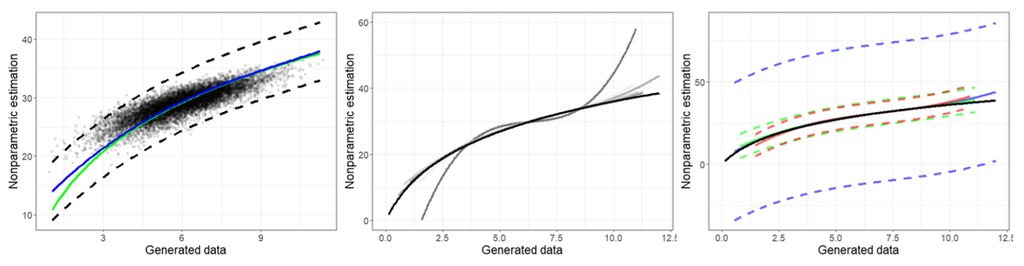

> [Burdett-Mortensen (1998) - Simulations](https://louissirugue.github.io/Burdett-Mortensen-1998-Simulations/burdettmortensen.html)

URL: https://louissirugue.github.io/Burdett-Mortensen-1998-Simulations/burdettmortensen.html

Github repo: https://github.com/LouisSirugue/Burdett-Mortensen-1998-Simulations

Description: Simulates the second extension (heterogenous firms) of the Burdett-Mortensen model (1998)

Sneak peek:

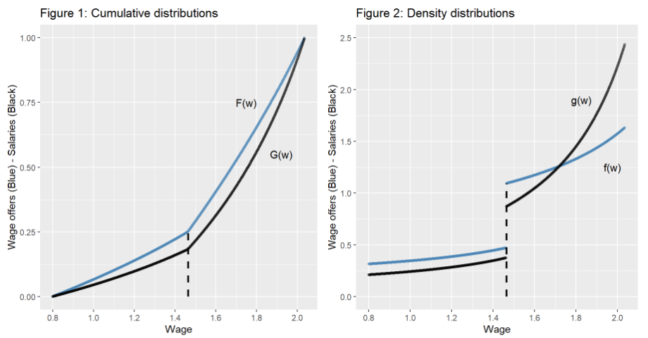

## Miscellaneous

> [Visualisation of the 100x100 US transition matrix](https://louissirugue.github.io/Visualizing-the-US-100x100-transition-matrix/index.html)

URL: https://louissirugue.github.io/Visualizing-the-US-100x100-transition-matrix/index.html

Github repo: https://github.com/LouisSirugue/Visualizing-the-US-100x100-transition-matrix

Description: Provides a visual representation of the US transition matrix

Sneak peek:

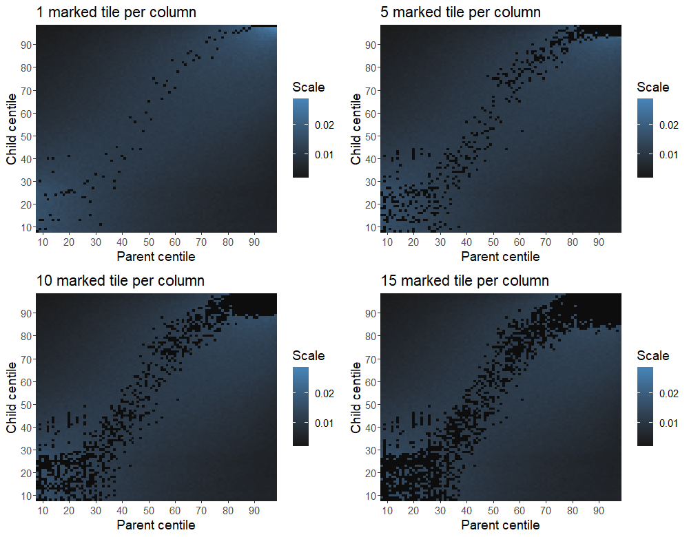

> [Directotree](https://louissirugue.github.io/directotree/package.html)

URL: https://louissirugue.github.io/directotree/package.html

Github repo: https://github.com/LouisSirugue/directotree

Description: Represents the content of a directory as an interactive collapsible tree. Offers the possibility to assign a text (e.g., a ‘Readme.txt’) to each folder (represented as a clickable node), so that when the user hovers the pointer over a node, the corresponding text is displayed as a tooltip.

Sneak peek:

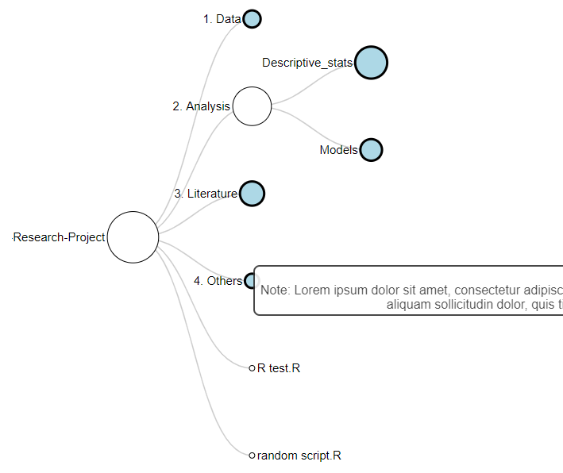

> [Magritte](https://louissirugue.github.io/Magritte-approximate-a-circle-with-straight-lines/magritte.html)

URL: https://louissirugue.github.io/Magritte-approximate-a-circle-with-straight-lines/magritte.html

Github repo: https://github.com/LouisSirugue/Magritte-approximate-a-circle-with-straight-lines

Description: Approximates a circle with n straight lines

Sneak peek:

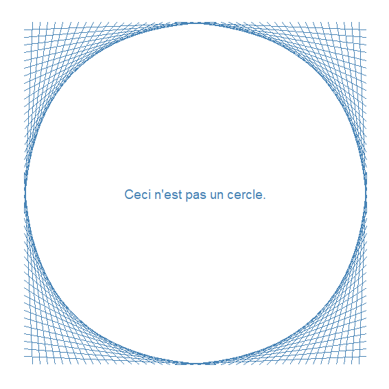